# Lab 5: Count Regression

- Show All Code
- Hide All Code
- View Source

Author

Alana Graham

## Introduction

In this lab, I will apply count regression to investigate the factors associated with how often older adults visit a physician’s office. Rather than fitting a single model, I will build up a Poisson model, check it with simulation-based residuals, move to a negative binomial (NB) model if the data call for it, decide whether the zeros need their own model, and then test and probe an interaction.

The `NMES1988` data follows 4406 adults aged 66 and older from the 1987–1988 US National Medical Expenditure Survey. The variables of interest are described below:

| Variable | Description |
| --- | --- |
| `visits` | **Outcome:** Number of physician office visits |
| `chronic` | Number of chronic conditions |
| `health` | Self-perceived health: `poor`, `average`, or `excellent` |
| `gender` | `male` or `female` |
| `school` | Years of education |
| `insurance` | Covered by private insurance: `no` or `yes` |

The reference groups are **Average Health**, **Male**, and **No Insurance**.

## Exploring the Data

| n | mean | var | % 0s | max |
| --- | --- | --- | --- | --- |
| 4406 | 5.77 | 45.69 | 0.16 | 89 |

As shown above, the outcome is a count (i.e., whole numbers, bounded at zero, and right-skewed), describing the number of physician’s office visits for each person (mean = 5.77). Notably, the variance is 7.91 times the mean, suggesting overdispersion. Additionally, 16% of the sample reported no visits, and 74 individuals visited a physician more than 25 times in 1987-1988. See the plot below for the distribution of responses for this outcome.

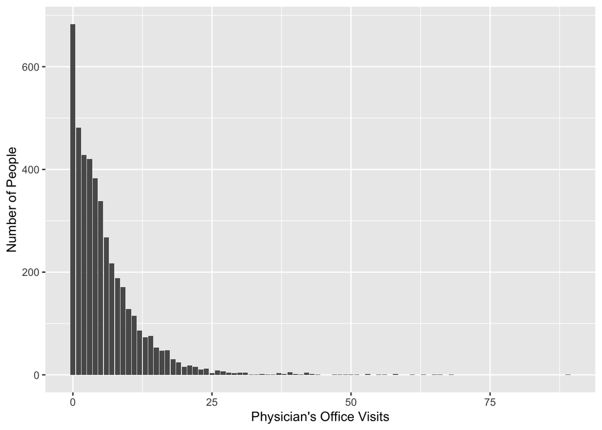

The DHARMa plots, below, depict substantial violations of Gaussian assumptions, suggesting that a linear model would be a poor fit for the data. The QQ plot shows a significant deviation from the expected residual distribution (KS test *p* < .001) and the residuals-versus-predicted plot reveals significant quantile deviations. Notably, if a linear model was used, it could predict negative article counts. Additionally, a Gaussian model assumes constant variance (i.e., puts mass on negative counts and too little mass at zeros) and treats effects as additive. On the other hand, count variance grows with the mean and it is more natural for a predictor to multiply the expected count.

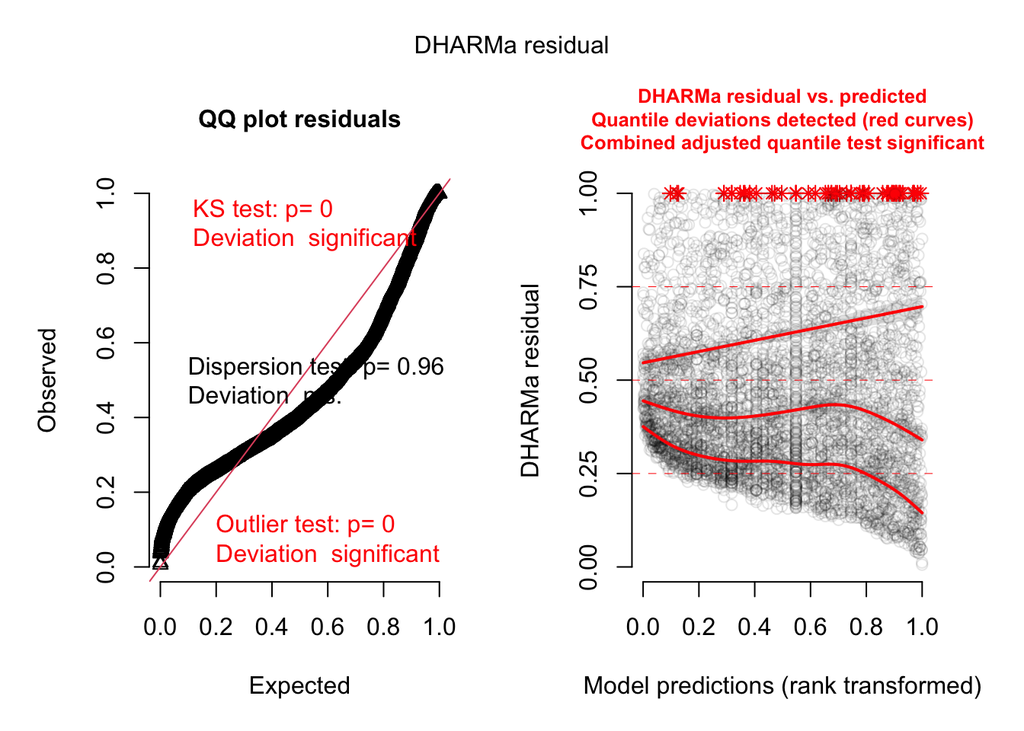

## Specifying Competing Count Models

I will fit an intercept-only model and two increasingly complex substantive models.

| Model | Formula | Research rationale |
| --- | --- | --- |
| null: Null | `visits ~ 1` | Baseline model |
| one_pred: Chronic | `visits ~ chronic` | Number of visits varies with number of chronic conditions |
| full poisson: Full | `visits ~ chronic + health + gender + school + insurance` | Other predictors explain additional variation |

The models are **nested**: Each successive model contains all predictors from the preceding model, plus one or more additional predictors.

| Model | AIC | BIC | Log-likelihood | Deviance | Residual.df | Nested df | Nested χ² | Nested p |
| --- | --- | --- | --- | --- | --- | --- | --- | --- |
| M0: Null | 39,720.34 | 39,726.73 | −19,859.17 | 26,942.92 | 4405 | — | — | — |
| M1: Chronic | 37,546.91 | 37,559.69 | −18,771.46 | 24,767.49 | 4404 | 1 | 2,175.43 | < .001 |
| M2: Full | 36,596.99 | 36,641.72 | −18,291.49 | 23,807.57 | 4399 | 5 | 959.92 | < .001 |

The degrees of freedom values reflect the difference in the number of parameters between a model and its precursor. The intercept-only model estimates the average number of physician’s office visits without accounting for any predictors.

## Poisson Diagnostic Tests

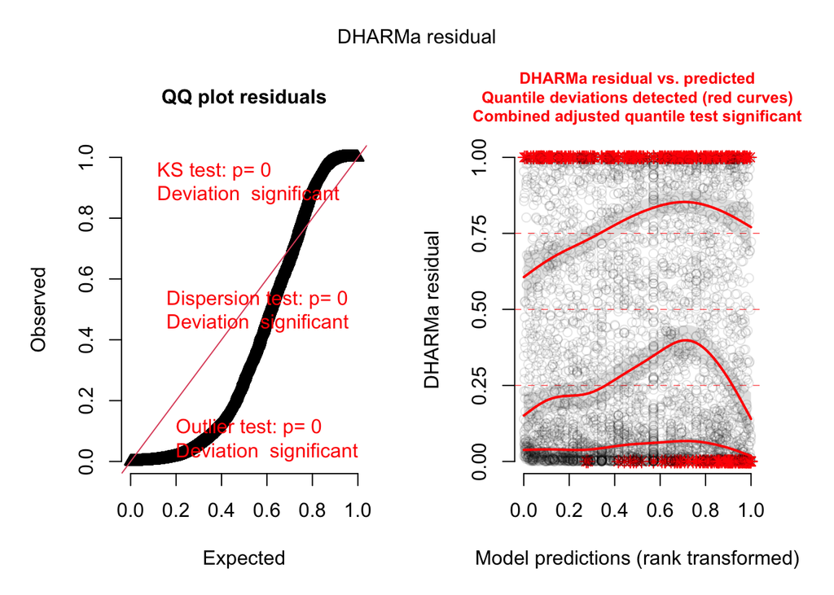

```r
# Formal dispersion test: is the observed variance bigger (or smaller) than the Poisson model expects?
# A significant p means the variance = mean assumption doesn't hold
disp_pois <- testDispersion(res_pois)
```

```r
disp_pois

# Zero-inflation test: does the data have more zeros than the Poisson predicts?
zi_pois <- testZeroInflation(res_pois)
```

[output not shown]

```r
zi_pois
```

[output not shown]

The dispersion ratio is 7.25 (*p* < .001), and there are 15.03 times as many zeros as the Poisson expects. The observed data are more variable than a Poisson allows. This matters because a Poisson’s standard errors assume variance = mean. When the data are overdispersed, those SEs are too small, CIs are too narrow, and *p*-values are too optimistic.

Although it may be tempting to fit a zero-inflation model based on the significant zero-inflation test, this test can only tell us that there is an abundance of zeros, but not their cause or how to treat them. This is particularly important to note, as a zero-inflated model treats zeros as coming from two distinct sources (i.e., structural and sampling), based on theoretical and empirical justifications. As a next step, then, I will fit and evaluate a negative binomial model, which may be better positioned to handle greater variability and excess zeros.

## Fitting Negative Binomial Model

| Df | AIC | BIC | logLik | deviance | Chisq | Chi Df | Pr(>Chisq) |
| --- | --- | --- | --- | --- | --- | --- | --- |
| 7 | 36596.99 | 36641.72 | -18291.49 | 36582.99 | NA | NA | NA |
| 8 | 24469.91 | 24521.03 | -12226.95 | 24453.91 | 12129.08 | 1 | 0 |

The negative binomial model fits the data significantly better than the Poisson model, χ²(1) = 12129.08, *p* < .001. As the key distinction between the two models is that the negative binomial introduces an additional parameter that allows the variance to exceed the mean, as denoted by the additional degree of freedom, this suggests that the overdispersion detected in the poisson diagnostic tests was a major issue. If I had continued with the poisson model, reports of statistical significance for individual predictors may have been overstated and the standard errors and confidence intervals may have been overly narrow, potentially leading to misinformed substantive conclusions. It’s worth noting that the coefficient estimates would have remained relatively similar. That said, diagnostic tests should also be run for the negative binomial model to examine whether excess zeros, influential observations, and uniformity of residuals remain issues of concern.

## Negative Binomial Diagnostic Tests

```r
# Same seed as before so the residuals are reproducible and comparable to the Poisson check.
set.seed(9041)

# If the NB is adequate, these should now be uniform, unlike the Poisson's.
res_nb <- simulateResiduals(neg_binom, n = 500, plot = FALSE)

# QQ plot: points should now sit close to the diagonal.
# Residuals vs. predicted: should be roughly flat.
plot(res_nb)
```

[output not shown]

```r
# Dispersion: the ratio should now be close to 1 and non-significant.
disp_nb <- testDispersion(res_nb)
```

```r
# Zero inflation: does the NB reproduce the observed number of zeros?
# A non-significant result means the NB's extra variance already accounts for the zeros, so there's no need for a zero-inflated or hurdle model.
zi_nb <- testZeroInflation(res_nb)
```

See below for a visualization of the predicted number of physician’s office visits (based on the additive negative binomial model), as predicted by the number of patients’ chronic conditions. The line curves upward even though the model is linear in its predictors because of the log link: Each additional chronic condition adds a constant amount on the log scale, which multiplies the expected count, so the same one-chronic-condition increase adds more visits when the expected count is already high.

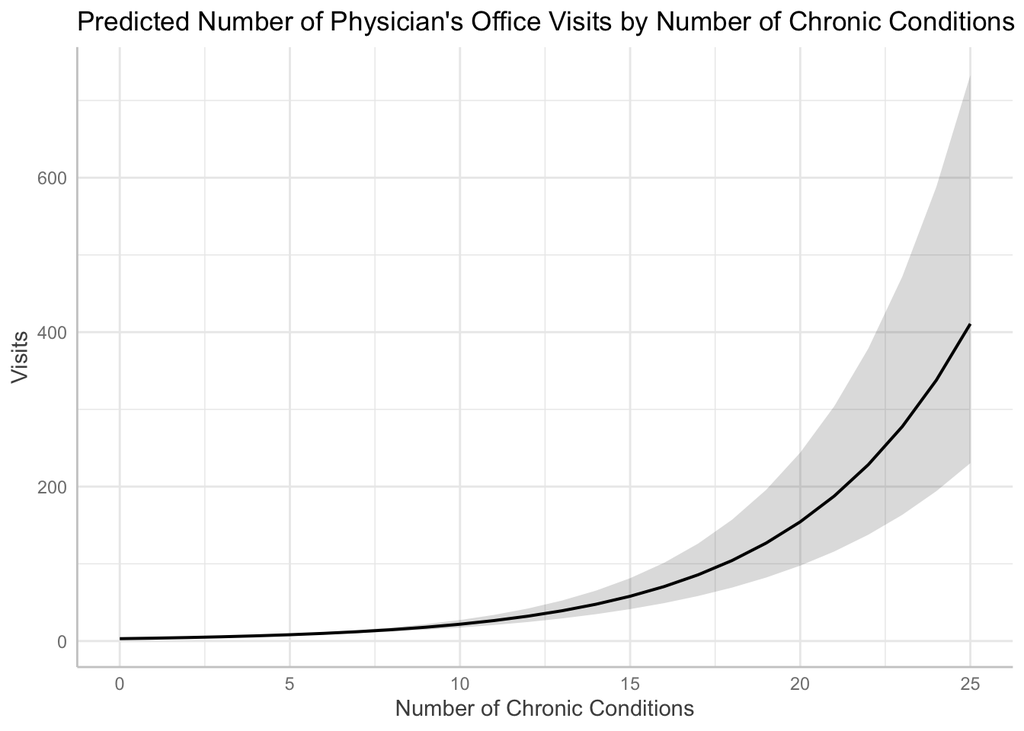

## Comparing Zero-Inflation and Hurdle Negative Binomial Models

It was not surprising to find that a full zero-inflation NB fits the data better than the standard NB model χ²(7) = 143.14, *p* < .001. When looking at the AIC and BIC values, however, it appears that the hurdle NB model fits the data even better Specifically, although the zero-inflation model has similarly low AIC (24340.77) and BIC (24436.63) values, the hurdle model’s AIC (24330.41) and BIC (24426.27) values are even lower.

```r
# Then re-check the chosen model with DHARMa
set.seed(9041)
res_hurd_nb <- simulateResiduals(m_hurd, n = 500, plot = FALSE)

res_hurd_nb_test <- testZeroInflation(res_hurd_nb)
```

Furthermore, the diagnostic tests also suggest that the hurdle NB model fits the data well, as the non-significant zero-inflation test suggests that this model already accounts for the zeros (statistic = 1, *p* = 1).

## Testing and Probing an Interaction

Now that I’ve chosen a model, I will examine whether the association between the number of chronic conditions and physician visits differs for people based on whether or not they have health insurance. I expect that for individuals with fewer chronic conditions, those who having insurance will predict a greater number of physician’s office visits. For those with a larger number of chronic conditions, I expect that the distinction between those with and without health insurance will narrow significantly, as individuals with many chronic conditions may have less opportunity or desire to avoid or decline medical care due to the increased negative impact of multiple chronic conditions on their health and well-being.

| Df | AIC | BIC | logLik | deviance | Chisq | Chi Df | Pr(>Chisq) |
| --- | --- | --- | --- | --- | --- | --- | --- |
| 15 | 24330.41 | 24426.27 | -12150.20 | 24300.41 | NA | NA | NA |
| 16 | 24332.07 | 24434.32 | -12150.03 | 24300.07 | 0.3409581 | 1 | 0.5592767 |

The interaction was not significant here, χ²(1) = 0.34, *p* = 0.559, but I will probe it below anyway to better understand the patterns of results and different levels of both chronic condition and insurance status.

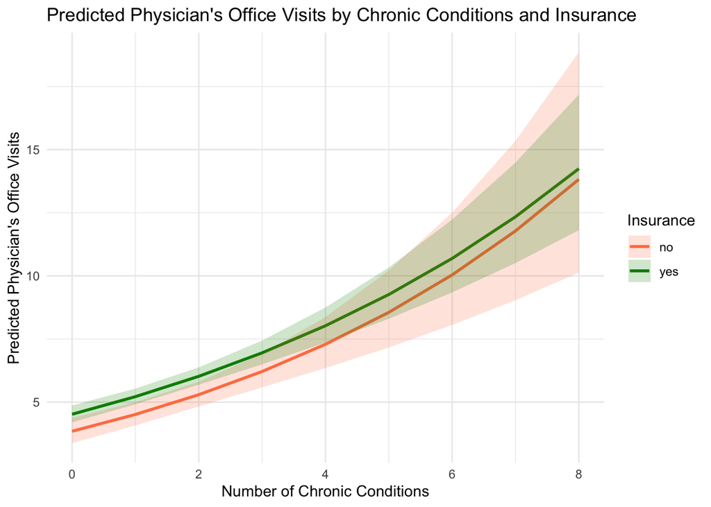

```r
# Simple slopes: the slope of chronic estimated separately for those with and without health insurance.
slopes <- emtrends(interact,
  specs = ~ insurance,
  var = "chronic")

pairs_slopes <- as.data.frame(pairs(slopes))

#test simple slopes against zero
slopes_sum <- summary(slopes, infer = TRUE)

slopes_sum
```

Whereas the simple slopes coefficients estimate the association between number of chronic conditions and physicians’ office visits separately for those with and without health insurance, the statistics (estimate, SE, *p*) from `pairs()` tests whether the two slopes (i.e., associations) differ. With only two levels of the moderator, this contrast reproduces the interaction coefficient from `summary(interact)` but with the opposite sign; `pairs()` computes no − yes, whereas simple slopes computes yes − no.

`ggeffects` (Step 3) holds categorical predictors at their respective reference levels, while `emmeans` *averages over* their levels. The insurance *contrasts* are equivalent in this case because with no interaction involving the other categorical predictors (i.e., health, gender), its effect cancels out of the comparison.

```r
# Simple effects: flip the probing around and look at the insurance difference at specific values of chronic condition number, instead of the chronic slope within each insurance response type

# Pick the probing values: low (-1 SD), average (mean) and high (+1 SD) chronic condition number
chronic_mean <- mean(data$chronic, na.rm = TRUE)
chronic_sd <- sd(data$chronic, na.rm = TRUE)
chronic_values <- chronic_mean + c(-1, 0, 1) * chronic_sd

# Estimated marginal means (EMMs) for each insurance response type at each chronic condition number value.
insurance_emmeans <- emmeans(interact,
  specs = ~ insurance | chronic,
  at = list(chronic = chronic_values))

# Estimated mean visits in each insurance x chronic cell.
summary(insurance_emmeans, type = "response")

# Insurance differences at each chronic value, on the log scale.
pairs(insurance_emmeans)

# Building a data frame of the simple effects
contrast_df <- summary(pairs(insurance_emmeans)) |>
  as.data.frame() |>
  mutate(chronic = rep(chronic_values, each = 1),
         chronic_level = c("-1 SD", "Mean", "+1 SD")[match(round(chronic, 6), round(chronic_values, 6))]) |>
  select(chronic_level, contrast, estimate, SE, z.ratio, p.value)
```

Simple Effects of Insurance Across Number of Chronic Conditions

Hurdle Negative-Binomial Regression

| Number of Chronic Conditions | Contrast | Log Contrast | SE | z | p |
| --- | --- | --- | --- | --- | --- |
| -1 SD | no - yes | −0.16 | 0.06 | −2.45 | 0.014 |
| Mean | no - yes | −0.14 | 0.04 | −3.06 | 0.002 |
| +1 SD | no - yes | −0.11 | 0.05 | −2.20 | 0.028 |

Log contrast = No − Yes; z-tests and p-values are computed on the log scale.

## Results

The current analysis investigated whether a variety of factors influenced the frequency of physicians’ office visits in the U.S.

#### Main Effects

Noting that all associations were adjusted for the other predictors in the model, the results of the **conditional** model (i.e., those who had 1+ visits) found that the number of chronic health conditions was significantly and positively associated with the expected number of physician’s office visits (*b* = 0.15, 95% CI [0.12, 0.17], *p* < .001). Individuals with more chronic conditions reported more physician’s office visits, holding the other predictors constant.

Poor health was significantly associated with a higher expected number of physician visits relative to average health (*b* = 0.38, 95% CI [0.29, 0.48], *p* < .001). Conversely, excellent health was significantly associated with a lower expected number of visits relative to average health (*b* = -0.37, 95% CI [-0.50, -0.24], *p* < .001).

Education was significantly and positively associated with the expected number of visits (*b* = 0.02, 95% CI [0.01, 0.03], *p* < .001).

Similarly, individuals with health insurance had a higher expected number of visits than those without insurance (*b* = 0.13, 95% CI [0.05, 0.22], *p* = 0.003).

Gender was not significantly associated with the expected number of visits. Although females had a slightly higher expected number of visits than males, this difference was not statistically significant (*b* = 0.06, 95% CI [-0.01, 0.12], *p* = 0.088).

In the **zero-inflation component**, which compared those with zero visits to all others, the number of chronic conditions was significantly and negatively associated with the likelihood of reporting zero physician visits (*b* = -0.56, 95% CI [-0.65, -0.47], *p* < .001). In other words, individuals with fewer chronic conditions had higher odds of reporting zero visits.

Excellent health was significantly and positively associated with the likelihood of reporting zero visits relative to average health (*b* = 0.31, 95% CI [0.03, 0.59], *p* 0.030). However, poor health was not significantly associated with the likelihood of reporting zero visits (*b* = -0.05, 95% CI [-0.36, 0.26], *p* = 0.754).

Education was also significantly and negatively associated with the likelihood of reporting zero visits (*b* = -0.06, 95% CI [-0.08, -0.03], *p* < .001).

Similarly, individuals with health insurance had significantly lower odds of reporting zero visits than those without insurance (*b* = -0.75, 95% CI [-0.94, -0.55], *p* < .001).

Females had significantly lower odds of reporting zero physician visits than males (*b* = -0.40, 95% CI [-0.57, -0.23], *p* < .001). As with the conditional model, all associations in the zero-inflation component were adjusted for the other predictors in the model.

#### Discussion

Taken together, the findings suggest that older adults’ healthcare utilization is strongly associated with their health needs, including the number of chronic conditions they have and their self-perceived health. For those who have made at least one physician’s office visit, self-perceived health had the largest individual influence. Other factors, including insurance status, education, and gender also seemed to influence the number of physician’s office visits. In particular, being insured, having a greater number of chronic health conditions, and being female were associated with much lower odds of having visited a physician’s office zero times.

The main limitation is that the cross-sectional nature of these data prevent causal conclusions. It is possible that the number of physician’s office visits is associated with the number of chronic health conditions as a predictor, outcome, or both. It is also possible that other variables not included in this analysis could play key roles in predicting the number of visits, both independently and as mediators/moderators. The use of self-report measures (e.g., self-perceived health status) may have also biased conclusions drawn from the data. Finally, the results are somewhat limited in their generalizability, as these data were taken specifically from older adults living in the U.S. Thus, it is not reasonable to extrapolate the findings outlined here to other populations.